# A guided tour of the ‘novelqualcodes’ package

# Aim of this document

This document (briefly) demonstrates how to use the *novelqualcodes* package to visualise the novelty and richness of semi-structured interviews over time.

# What is *novelqualcodes*?

*novelqualcodes* is a package aimed at qualitative researchers doing semi-structured interviews using the ‘framework’ method. Its main focus is to provide a transparent solution to reporting when refinements were made to questions during the interview process, and how that informs the researchers’ decision to stop interviews (the *stopping point*). Its secondary focus is to allow researchers to visualise the novelty and richness of interviews as they are coded so that it can be part of the decision-making process regarding the stopping point.

*novelqualcodes* does this by importing ‘coding matrices’ that are exported from *NVivo*’s **Matrix Coding Query** tool and tracking the trends of *novel* and *duplicate* codes across interviews. Briefly:

- A **novel code** is a topic/idea/concept that has not been mentioned in an interview before. For example, a novel code is a topic that was mentioned in Interview 17, but which was not mentioned in Interviews 1 through 16.
- A **duplicate code** is one that has been talked about in other interviews previously.

*novelqualcodes* gets information about refinements by importing a spreadsheet of field notes where you have recorded when refinements were made, what was done, and why it was done. Code trends and refinements are displayed together in publication-ready plots.

You can read more about the methodology of this package in:

> Wong, K. C., Trankle, S. A., Quintans, D., Nguyen, T. N., Usherwood, T., & Chow, C. K. (2023). *A Systematic Approach to Improving the Transparency of Interview Refinements and Data Sufficiency in Semi-Structured Interviews: An Illustration Using the Mass Atrial Fibrillation Screening Study.* International Journal of Qualitative Methods, 22. https://doi.org/10.1177/16094069231220773

# Installing *novelqualcodes*

## Step 1. Install *R*

To run this package, you need to have the *R* statistical programming language installed. You can download it from https://cran.r-project.org/; pick *Download R for {your platform}* and follow the links to download an installer, and then run the installer.

## Step 2. Run an *R* editor

*R* comes with a simple editor called `RGui.exe`, located in the installation directory. If you want something a little easier to use that has more features, you can download and install *RStudio* from https://posit.co/download/rstudio-desktop/.

Either way, start your chosen editor and you’ll be greeted with the *R* console. Basic information about how to use *R* is outside the scope of this guided tour; ample resources exist on the internet.

## Step 3. Install *novelqualcodes*

You can install the package by running (i.e. type this in the console and hit *Enter*) the function:

```r
install.packages("novelqualcodes")
```

You only need to install the package once; you don’t need to run this if you’ve installed it previously.

## Step 4. Attach the package to the session

Right now, the package is installed on your computer but has not been called up for use. To do so, run:

```r
library(novelqualcodes)
```

# Input files used by the package

*novelqualcodes* needs two kinds of input files from you: **field notes** and **coding matrices**.

## Field notes (of refinements)

This package accepts an Excel spreadsheet where you’ve recorded the refinements you’ve made to the interview process as you ran the study.

You can get a template of this spreadsheet by running the function:

```r
create_field_notes_template("C:/path/to/save/this/to")
```

Or by creating a spreadsheet in Excel with these column names and saving it in Excel (.XLSX) format:

1. `interview_num` is the upcoming interview number where these refinements will take effect. At the time of writing, this is the only column that is used by the package; the rest is for your record-keeping.
2. `refinement_type` is free text where you can describe the kind of refinement you made, e.g. “add” or “rephrase” or “remove”.
3. `refinement` is the actual text that has been changed.
4. `reason` describes the rationale behind the refinement.
5. `other` is for additional information you may want to include.

## Coding matrices

For our purposes, a coding matrix is an Excel spreadsheet where each row is a unique code, and each column shows how many times that code was mentioned in one interview. *NVivo*’s **Matrix Coding Query** tool can produce spreadsheets in the correct format, which we detail below.

### Getting coding matrices from *NVivo*

1. In *NVivo*, click **Explore** then **Matrix Coding Query**. A new pane will open with two large boxes: one labelled *Rows* and the other labelled *Columns*.

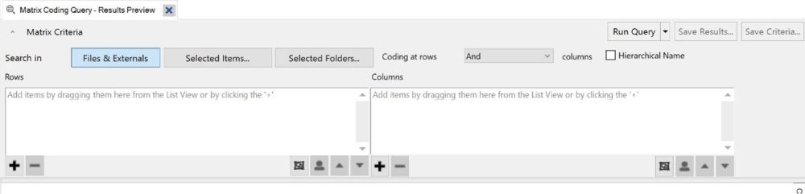

2. Click the **+** button under the *Rows* box and select all **Codes**.

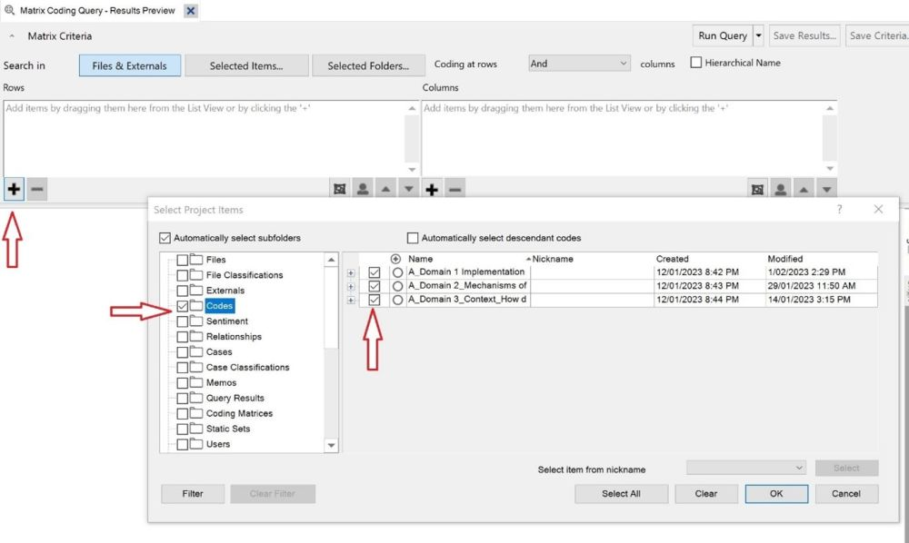

3. Click the **+** button under the *Columns* box and select only one **case** (participant/interview).
   - This package requires that there must be only one case per coding matrix. This is because we expect users to export coding matrices as the study progresses.

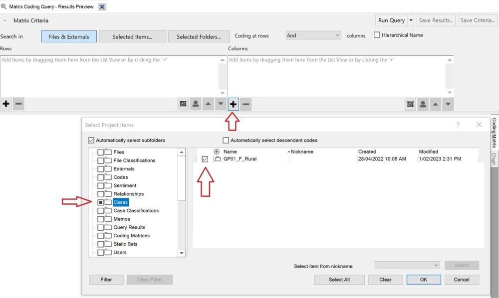

4. Click **Run Query**. The coding matrix will be generated.
   - You *do not* need to remove rows with a count of 0 (a code that was not mentioned by the interviewee). They will be ignored by *novelqualcodes*.

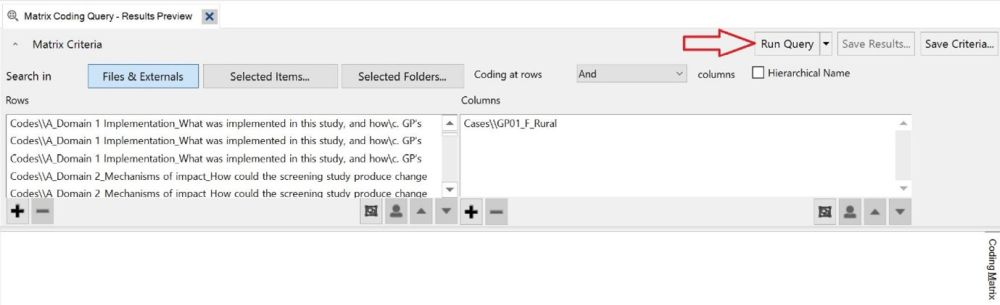

5. Right-click the matrix that was just created and select **Export Coding Matrix**.

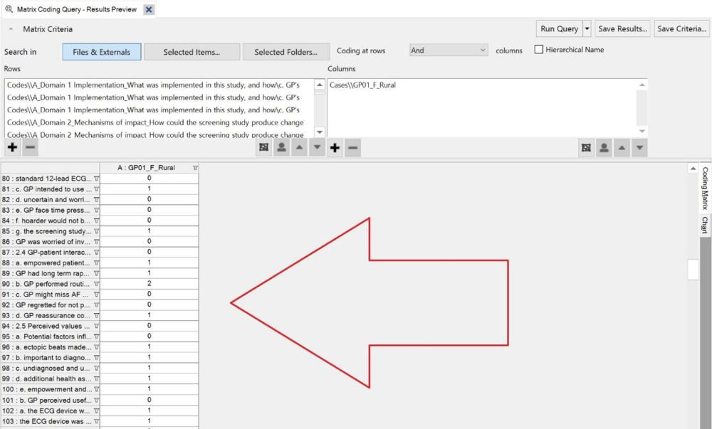

6. Give it a filename that starts with the interview’s sequence number or datetime (in YYYY-MM-DD HHMM format).
   - *Filenames are important!* They are used to sort interviews chronologically to decide which codes are novel (not mentioned in previous interviews) and which are not. The two examples below will sort correctly.
   - Example 1 (interview number): `Int006_P12` for the 6th interview you conducted in the study, belonging to participant ID 12.
   - Example 2 (datetime): `2023-07-14 1355 P56` for an interview you conducted on 2023-07-14 at 13:55, with participant ID 56.
7. Save the file as a Microsoft Excel (.XLSX or .XLS) spreadsheet.

[figure not shown]

8. Put all of your exported coding matrices in the same folder, and **separate from the field notes**.

[figure not shown]

# A worked example of an analysis with *novelqualcodes*

## File structure

Imagine that you are interested in public perceptions of insects. You’ve interviewed 15 people, you’ve made a few refinements, and you want to see how things are going. You have exported coding matrices for the 15 interviews from *NVivo* and put them into **C:/insect_study/matrices/**. You also have a field notes spreadsheet, located at **C:/insect_study/records/refinements.xlsx**. So your file structure looks like this:

[output not shown]

Your refinements spreadsheet looks like this:

```
interview_num   refinement_type refinement          reason                  other
6               add             Can you tell...     Understand publi...
9               add             Why don't yo...     Get participants...
13              add             Is that how ...     feel about most ...
```

And your matrices look generally like this (note that it is fine to have zeroes in this matrix; they will be removed automatically):

[output not shown]

## Step 0. Start R and load *novelqualcodes*

As detailed above in the section Installing *novelqualcodes*, we’ll start *R* and install the package if we haven’t done that yet.

Now we’ll load the package to make it ready to use:

```r
library(novelqualcodes)
```

## Step 1. Import field notes and interviews

First, let’s import the field notes and name it `my_refinements` for later use:

```r
my_refinements <- import_field_notes(path = "C:/insect_study/records/refinements.xlsx")
```

Field notes are optional; if you do not have any field notes, then you can skip importing them.

Second, we can import all of the interviews in the *matrices/* folder and name it `nvivo_matrices`:

```r
nvivo_matrices <- import_coding_matrices(path = "C:/insect_study/matrices")
```

```
#> ( 1 / 15) Reading Int01_ID731.xlsx
#> ( 2 / 15) Reading Int02_ID121.xlsx
#> ( 3 / 15) Reading Int03_ID54.xlsx
#> ( 4 / 15) Reading Int04_ID31.xlsx
#> ( 5 / 15) Reading Int05_ID33.xlsx
#> ( 6 / 15) Reading Int06_ID12.xlsx
#> ( 7 / 15) Reading Int07_ID17.xlsx
#> ( 8 / 15) Reading Int08_ID85.xlsx
#> ( 9 / 15) Reading Int09_ID77.xlsx
#> (10 / 15) Reading Int10_ID32.xlsx
#> (11 / 15) Reading Int11_ID21.xlsx
#> (12 / 15) Reading Int12_ID72.xlsx
#> (13 / 15) Reading Int13_ID14.xlsx
#> (14 / 15) Reading Int14_ID18.xlsx
#> (15 / 15) Reading Int15_ID112.xlsx
```

```
#> 15 files were read.
```

**Important note:** `import_coding_matrices()` imports **any and all** Excel spreadsheets that it finds in the folder. This is why you should keep your field notes and any other Excel spreadsheets in a different place to avoid errors!

## Step 2. Count novel and duplicate codes

With the coding matrices imported, *novelqualcodes* now has enough information to score novel and duplicate codes. Let’s do that now and name the result `code_results` for later use:

```r
code_results <- score_codes(nvivo_matrices)
```

Looking at the result, we get a count of how many codes were mentioned in each interview (`n_codes`), how many of those were not mentioned in previous interviews (`n_novel`), how many were previously mentioned (`n_duplicate`), and the proportion and cumulative sums of codes.

```r
print(code_results)
```

```
#>    itvw_seq n_codes n_duplicate n_novel prop_duplicate prop_novel cumsum_novel
#> 1         1       5           0       5      0.0000000  1.0000000            5
#> 2         2       4           0       4      0.0000000  1.0000000            9
#> 3         3       4           1       3      0.2500000  0.7500000           12
#> 4         4       2           1       1      0.5000000  0.5000000           13
#> 5         5       4           3       1      0.7500000  0.2500000           14
#> 6         6       3           2       1      0.6666667  0.3333333           15
#> 7         7       4           4       0      1.0000000  0.0000000           15
#> 8         8       3           3       0      1.0000000  0.0000000           15
#> 9         9       4           4       0      1.0000000  0.0000000           15
#> 10       10       2           2       0      1.0000000  0.0000000           15
#> 11       11       3           3       0      1.0000000  0.0000000           15
#> 12       12       3           3       0      1.0000000  0.0000000           15
#> 13       13       4           4       0      1.0000000  0.0000000           15
#> 14       14       4           4       0      1.0000000  0.0000000           15
#> 15       15       3           3       0      1.0000000  0.0000000           15
```

## Step 3. Plot the ‘novelty’ of interviews

In the most basic sense, the ongoing generation of novel codes shows that new information is being generated in the study. By showing novel codes in context with any refinements to the questions, it shows how that trend may have been affected by those refinements, and whether novel code generation is plateauing.

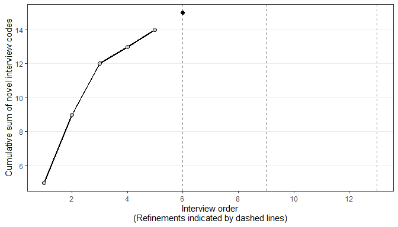

```r
plot_novelty(score_df = code_results, refinements = my_refinements)
```

In a real-world situation this might suggest that a) our refinements were not properly targeted, or b) we have generated enough information and it might be time to stop interviews. However, this chart alone should not be used to decide on a stopping point because it does not show the richness (i.e. detail, broadness) of individual interviews, which is the job of our next plot.

If you did not import any field notes in Step 1, then you can run this function without any refinements:

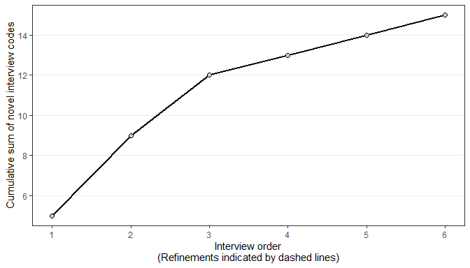

```r
plot_novelty(score_df = code_results)
```

Or if you know when you made refinements but don’t want to make a field notes file, you can provide the interview numbers directly:

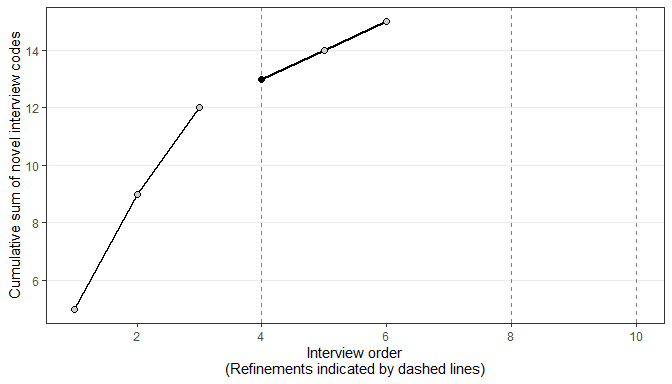

```r
plot_novelty(score_df = code_results, refinements = c(4, 8, 10))
```

### Saving a recent plot to a file

If we want to save the most recent plot to a 10 x 5 cm image for use in a paper, we can run:

```r
save_last_plot(filename = "C:/insect_study/plots/novelty.png",
               size = "10 x 5 cm", dpi = 300)
```

## Step 4. Plot the ‘richness’ of interviews

In a real semi-structured interview scenario, some interviews will touch on many different topics while others will be quite brief; we call this ‘richness’.

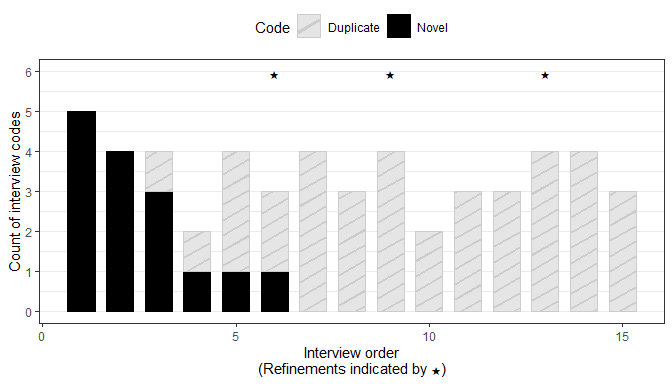

```r
plot_richness(score_df = code_results, refinements = my_refinements)
```

Again, if you did not import any field notes in Step 1 then you can run this function without any refinements:

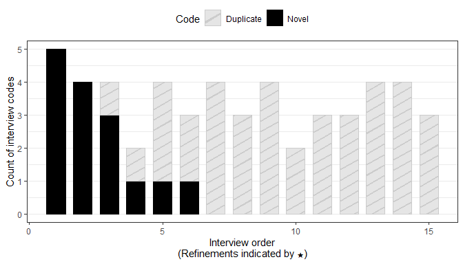

```r
plot_richness(score_df = code_results)
```

Or if you know when you made refinements but don’t want to make a field notes file, you can provide the interview numbers directly:

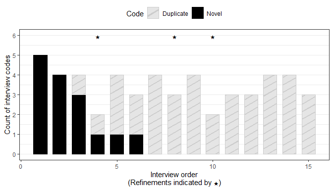

```r
plot_richness(score_df = code_results, refinements = c(4, 8, 10))
```

## Step 5. Getting help from *R*

*R*’s shortcut for help is `?{topic}`. Try running these in the Console if you want to know more about the functions we’ve just used:

```r
?novelqualcodes

?import_field_notes
?import_coding_matrices
?score_codes
?plot_novelty
?plot_richness
```

# Conclusion

We hope that this package is helpful to your research efforts. If you encounter any bugs or issues with it, please file an Issue at https://github.com/DesiQuintans/novelqualcodes/issues.